# Machine Learning Project FIFA Presentation

## Neural network

## single layer

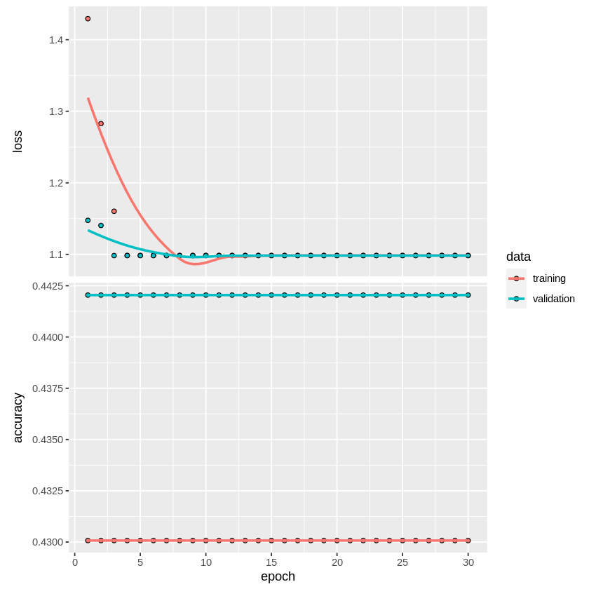

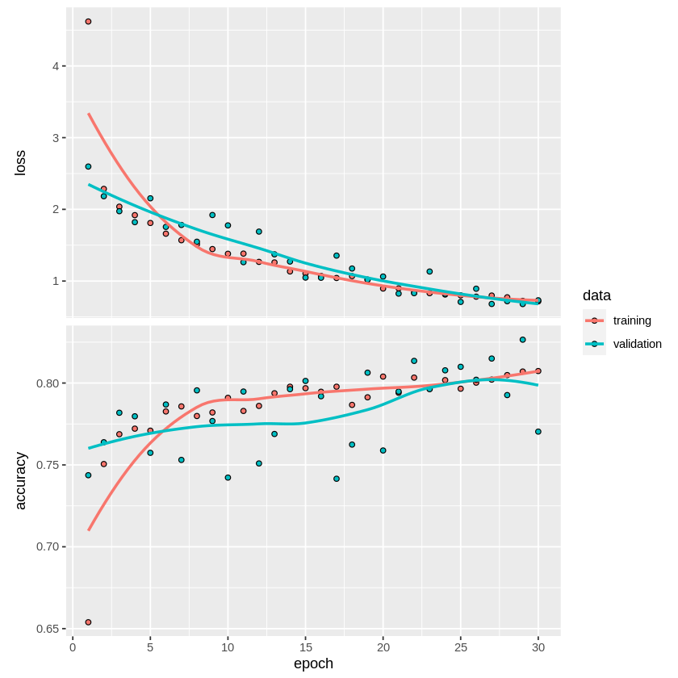

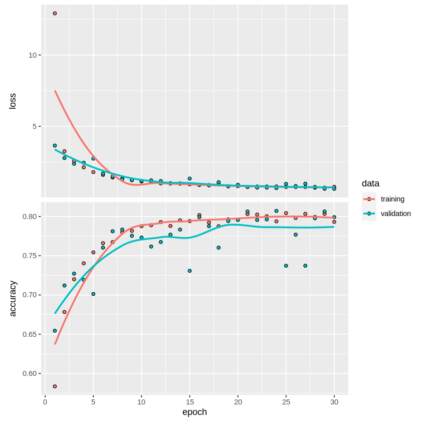

Neural netwwork single layer

## two layers

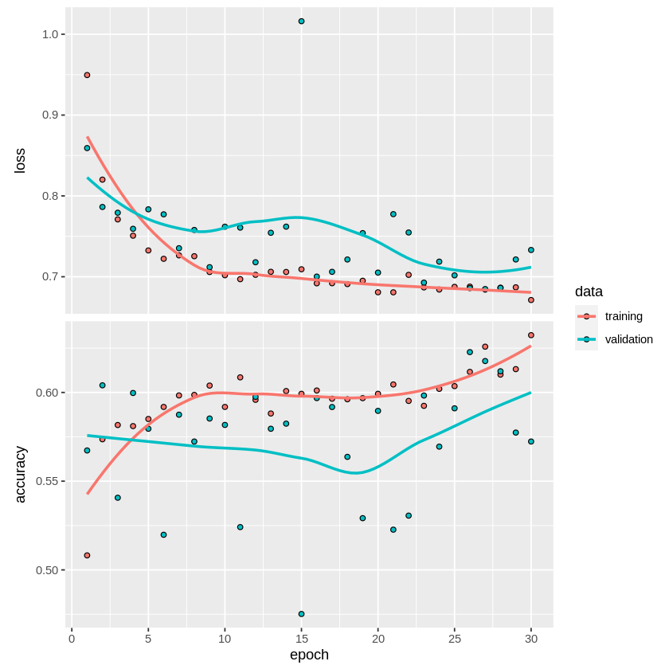

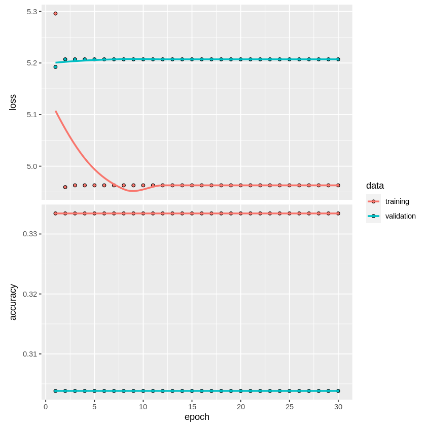

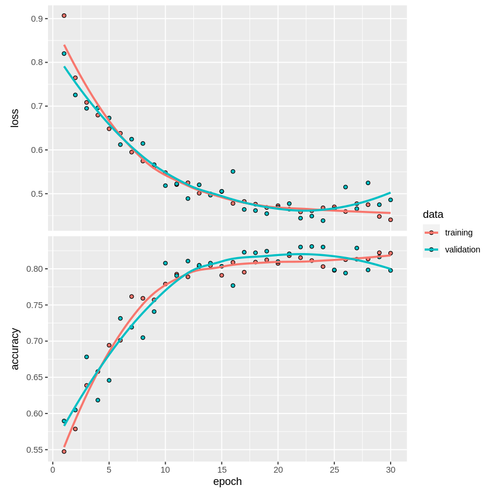

Neural netwwork two layer

## three layers

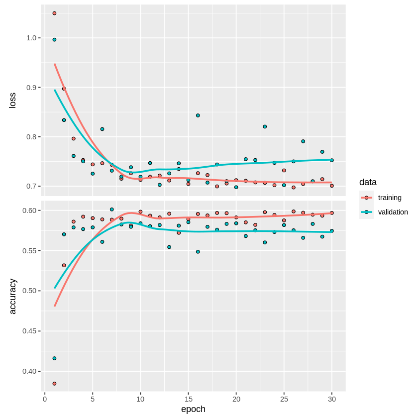

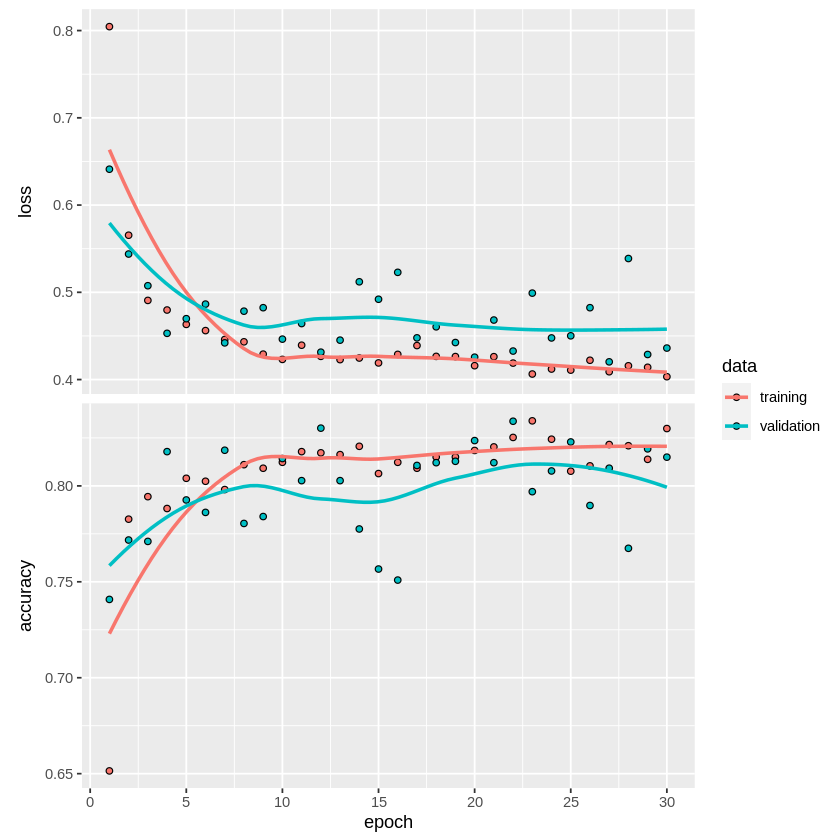

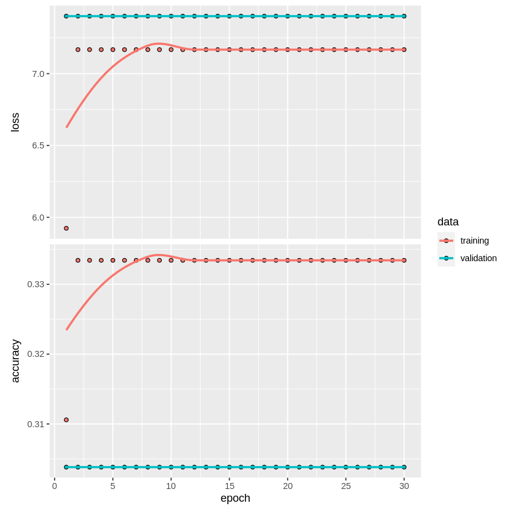

Neural netwwork three layer

## Nouveau modèle

```r
#model = keras_model_sequential()
#model %>% layer_dense(units=200, activation="sigmoid", input_shape=length(x_train[1,]))
#model %>% layer_dense(units=100, activation="relu")
#model %>% layer_dense(units=50, activation="sigmoid")
#model %>% layer_dense(units=25, activation="relu")
#model %>% layer_dense(units=12, activation="sigmoid")
#model %>% layer_dense(units=3, activation="softmax")
#model %>% compile(loss="sparse_categorical_crossentropy",optimizer="adam",metrics='accuracy')
#summary(model)
#history=model%>% fit(x=x_train_mid, y=y_train_mid, epochs=50, batch_size=5,validation_split=0.3)
#plot(history)
#model %>% evaluate(x_test_mid, y_test_mid)
```

## Visualisation de ce modèle

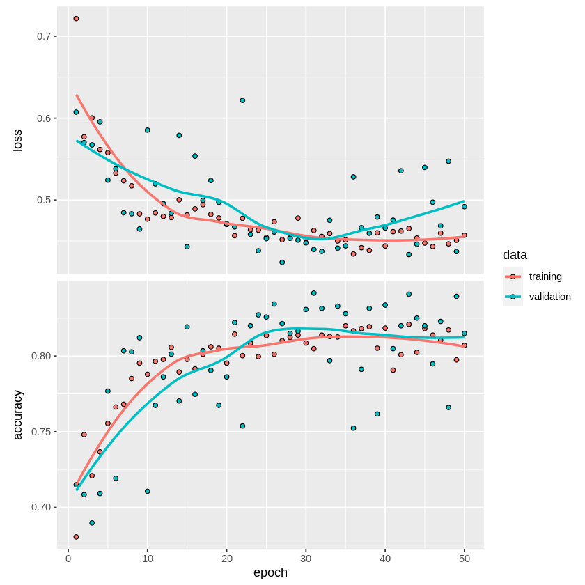

modèle finale

Nous obtenons une accuracy de 82%

## Comparaison (att & mid & def)

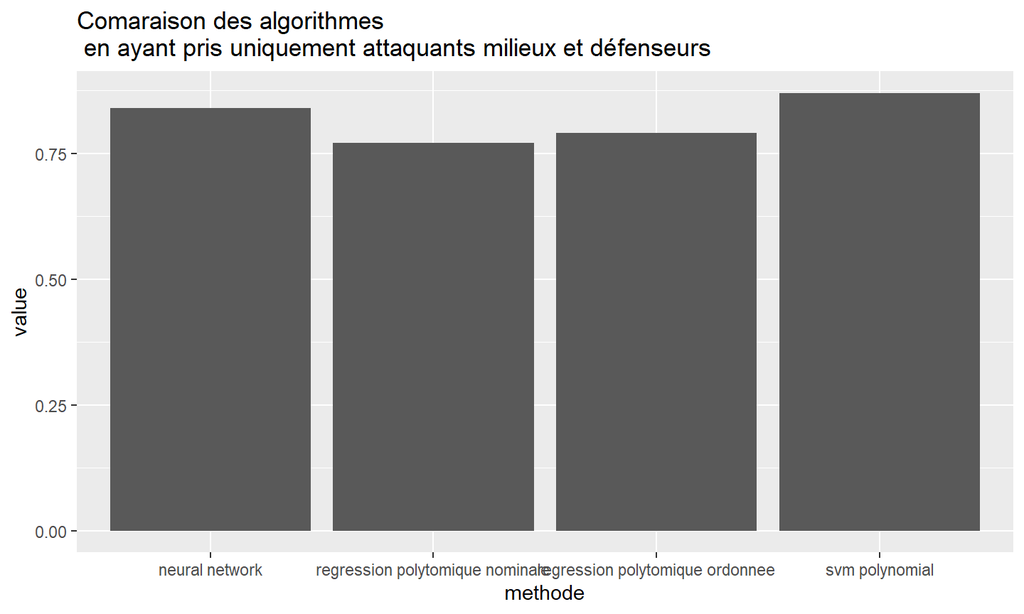

## Conclusion

- Machine Learning est désormais largement utilisé dans le football.
- Quel que soit la méthode utilisée, nous obtenons plus de 98% accuracy en séparant attanquants et défenseurs
- Les résultats obtenus en incluant les milieux dans l’analyse sont moins bon
- Avec 86% d’accuracy, SVM est la méthode à privilégié pour classer attaquants, milieux et défenseurs. On obtient “seulement” 84% avec un réseau de neurones à 6 couches.